# Topic Modeling for COVID19

COVID 19 has been the biggest pandemic people have seen in the recent times. It almost feels like one of those apocalyptic movies in real life. People hiding in their homes trying to save themselves from the infection. Some brave souls trying to find a better destination to survive this pandemic. With so much happening around the world, I have one question. **What are people around the world thinking about COVID 19?**

In this notebook, we will try to answer the above question using Topic Modeling. Let's explore the various topics people are talking about Corona Virus Disease 2019(COVID-19) in Twitter.

```python
# Import all required libraries
import os
import json
import requests
import re

# Twitter data collection library
import tweepy as tw

# Data processing libraries
import pandas as pd
import matplotlib.pyplot as plt
import numpy as np

# Loading Gensim and nltk libraries
import gensim
from gensim.utils import simple_preprocess
from gensim.parsing.preprocessing import STOPWORDS
import nltk
nltk.download('wordnet')

from nltk.stem import WordNetLemmatizer, SnowballStemmer
from nltk.stem.porter import *
import numpy as np

# NLTK Stop words
from nltk.corpus import stopwords
stop_words = stopwords.words('english')
#stop_words.extend(['from', 'subject', 're', 'edu', 'use', 'not', 'would', 'say', 'could', '_', 'be', 'know', 'good', 'go', 'get', 'do', 'done', 'try', 'many', 'some', 'nice', 'thank', 'think', 'see', 'rather', 'easy', 'easily', 'lot', 'lack', 'make', 'want', 'seem', 'run', 'need', 'even', 'right', 'line', 'even', 'also', 'may', 'take', 'come'])
#Other stop_words: gensim.parsing.preprocessing.STOPWORDS
```

```python
# Configure notebook display to show data from pandas dataframe more clearly.
pd.set_option('display.max_rows',500)
pd.set_option('display.max_columns',500)
pd.set_option('display.width',100)
pd.set_option('display.max_colwidth',800)
```

# 1. Gather the textual data for Topic Modeling

To begin with the topic modeling we need the textual data. The textual data for what people are talking about COVID 19 can be pulled from many places such as social media, news articles, web scraping etc. In this notebook, we'll download the data from Twitter. Tweepy is an amazing library to pull data from twitter using your Twitter Developer Account.

## Extracting tweets from Twitter API:

To load the data from Twitter using Tweepy API, you'll have to create Developer account with Twitter. Then download the credentials to authenticate using Tweepy API. **Please do not share these credentials with anybody else.**

- Here is the link to [apply for twitter developer access](https://developer.twitter.com/en/apply-for-access)
- You can follow the below code to use Tweepy API to authenticate and load the data. Here is the [Tweepy Documentation for reference](http://docs.tweepy.org/en/latest/)

```python
'''
LoadFromTwitter -
    If true, pull the latest set of tweets from Twitter using the Tweepy library.
    If false, load the data from the datafile '../data/tweets.csv' if it exists,
    otherwise load the tweets from Twitter using the Tweepy library.
    Set the LoadFromTwitter to True if you want to override loading the tweets afresh from twitter.
'''
LoadFromTwitter = False

fileName = '../data/tweets.csv'
tweetsDF = None

# Load the data
if os.path.exists(fileName) and not LoadFromTwitter:
    tweetsDF = pd.read_csv(fileName)
else:
    from TwitterDevSecrets import getTwitterDevCreds
    consumer_key, consumer_secret, access_token, access_secret = getTwitterDevCreds()

    auth = tw.OAuthHandler(consumer_key, consumer_secret)
    auth.set_access_token(access_token, access_secret)

    # Set the wait_on_rate_limit and wait_on_rate_limit_notify to True
    # wait_on_rate_limit –
    #    Whether or not to automatically wait for rate limits to replenish
    # wait_on_rate_limit_notify –
    #    Whether or not to print a notification when Tweepy is waiting
    #    for rate limits to replenish
    api = tw.API(
        auth,
        wait_on_rate_limit=True,
        wait_on_rate_limit_notify=True)

    # Define the search term and the date_since date as variables
    search_words = "#covid OR #covid19 OR #COVID OR #COVID19 OR #ncov OR #corona OR #coronaviru"
    date_since = "2020-05-16"

    # Read the tweets
    tweets = tw.Cursor(api.search,
                   q=search_words,
                   lang="en",
                   since=date_since)

    # extract the data in pandas dataframe
    # Other parameters: tweet.user.screen_name, retweet_counts, favorite_counts
    tweetsDF = pd.DataFrame()
    for tweet in tweets.items(10000):
        id = tweet.id
        text = tweet.text
        loc = tweet.user.location
        tweetsDF = tweetsDF.append({'Id':id, 'Text':text, 'Location':loc},ignore_index=True)

    tweetsDF['index'] = tweetsDF.index

    # Save the new set of tweets in the file.
    tweetsDF.to_csv(fileName,index=False)
```

Let's see how does the textual data look like.

```python
tweetsDF.Text[1]
```

```
'RT @Carol_D_Johnson: Thank you nurses for helping to keep us healthy  ❤ #COVID19 \n#StayHomeSaveLives \n#coronavirus https://t.co/HGv0HfuTgt'
```

# 2. Data preprocessing

As you can see from the above text, a tweet contains a lot of textual data which probably doesn't contain any useful informaiton for Topic Modeling. So, these tweets needs to be processed to extract only useful textual data for further analysis. We will perform the following data processing steps:

  >   > **PorterStemmer**: is known for simplicity and ease. The algorithm does not follow linguistics rather a set of rules that are applied in phases (step by step) to generate stems. This is the reason why PorterStemmer does not often generate stems that are actual English words.  
  >   > **SnowballStemmer**: One can generate their own set of rules for any language. Python nltk introduced SnowballStemmers that are used to create non-English Stemmers!  
  >   > **LancasterStemmer**: is simple, but heavy stemming due to iterations and over-stemming may occur. Over-stemming causes the stems to be not linguistic, or they may have no meaning.

```python
# Perform data preprocessing for all tweets.
stemmer = SnowballStemmer("english")

def lemmatize_stemming(text):
    return stemmer.stem(WordNetLemmatizer().lemmatize(text, pos='v'))

def tweet_cleanup(text):
    # Remove the leading RT from the tweet
    text = text.replace('RT','')
    # Remove the references to the account names starting with '@'
    text = re.sub(r'(@[a-zA-Z]*)','',text)
    # Remove the urls in the tweet.
    text = re.sub(r'((https?):((//)|(\\\\))+([\w\d:#@%/;$()~_?\+-=\\\.&](#!)?)*)','',text)

    return text

# Clean up the tweets and then Tokenize and lemmatize
def preprocess(text, stop_words=stop_words):
    result=[]
    text = tweet_cleanup(text)
    for token in gensim.utils.simple_preprocess(text) :
        if token not in stop_words and len(token) > 3:
            result.append(lemmatize_stemming(token))
    return result
```

```python
# Test the preprocessing step on a sample tweet
tweet_num = 0
sampleTweet = tweetsDF[tweetsDF['index'] == tweet_num].Text.iloc[0]

print("Original tweet: ")
words = []
for word in sampleTweet.split():
    words.append(word)
print(words)
print("\n\nPreprocessed tweet: ")
print(preprocess(sampleTweet))
```

```
Original tweet:
['RT', '@ALPublicHealth:', 'State', 'Health', 'Officer', 'Dr.', 'Scott', 'Harris', 'has', 'issued', 'a', 'stay', 'at', 'home', 'order', 'and', 'strict', 'quarantine', 'requirements.', 'Read', 'our', 'full…']


Preprocessed tweet:
['state', 'health', 'offic', 'scott', 'harri', 'issu', 'stay', 'home', 'order', 'strict', 'quarantin', 'requir', 'read', 'full']
```

```python
# Preprocess all tweets and generate a new processed tweet text dataset.
processed_tweets = tweetsDF['Text'].map(preprocess)
processed_tweets[:10]
```

```
0        [state, health, offic, scott, harri, issu, stay, home, order, strict, quarantin, requir, read, full]
1                                                      [thank, nurs, help, keep, healthi, covid, coronavirus]
2                                                                        [togetherapart, slow, spread, covid]
3                    [smoker, greater, risk, contract, coronavirus, elli, cannon, say, equal, risk, contract]
4                                      [video, model, scan, show, extent, covid, damag, lung, tissu, stayhom]
5                      [leader, hous, parti, caucus, arizona, andi, bigg, think, spread, covid, much, possib]
6                                                                                     [covid, test, administ]
7           [keep, think, master, public, health, write, doctor, dissert, global, effort, tackl, aid, pandem]
8    [ceylonblacktea, rich, theaflavin, help, increas, human, immun, covid, srilankatea, industri, successfu]
9                                     [peopl, first, group, hospit, sick, place, infirmari, convert, convent]
Name: Text, dtype: object
```

# 3. Text representation

Computers don't understand natural language texts. Text is a mere sequence of letters for computers. While its still difficult for computer to understand what the sequence of letters mean, language is way more complicated than that. For an example, let us consider an idiom "Kicked the bucket". You know where I am going right? When I first heard that phrase as a kid I thought it meant someone was actually kicking a bucket. That's fun! But, when I realized that it meant someone died, it was no more fun! So, natural language is hard and computers don't understand it.

Computers love numbers. At the core, computers perform their operations on numbers. So, it'd be good to represent the natural language text with numbers for computer algorithms to process easily. In the below section, we'll explore two different models for text representation namely Bag of words and TF-IDF.

# 3.1: Bag of words on the dataset

Create a dictionary of words present in the preprocessed_tweets dataset. Gensim offers a great api for the same. This dictionary assigns a numerical id to each word so that you can work on the number representations of the word. This makes the data processing very easy than working on strings.

Then create a corpus of Bag of words where words are represented by their numerical ids along with the frequency of occurence of that word in the tweet for further processing.

```python
dictionary = gensim.corpora.Dictionary(processed_tweets)

# Create Corpus: Term Document Frequency
corpus = [dictionary.doc2bow(text) for text in processed_tweets]
```

```python
# Check the id to word mapping from the dictionary created above
count = 0
for k, v in dictionary.iteritems():
    print(k, v)
    count += 1
    if count > 5:
        break
```

```
0 full
1 harri
2 health
3 home
4 issu
5 offic
```

Since the text corpus is very huge and sparse, we should try to minimize the amount of text being used for modeling. For this reason, let us remove very rare and very common words. Gensim dictionary object provides a good api to perform this operation.

- words appearing less than 15 times
- words appearing in more than 10% of all documents

Then convert it into bag of word corpus with very rare and very common wordsd filtered out.

```python
dictionary.filter_extremes(no_below=15, no_above=0.1, keep_n=100000)
bow_corpus = [dictionary.doc2bow(doc) for doc in processed_tweets]

# Test the Bag of Words representation of the tweet --> (token_id, token_count)
bow_corpus[tweet_num]
```

```
[(0, 1), (1, 1), (2, 1), (3, 1), (4, 1)]
```

```python
# Preview BOW for our sample preprocessed tweet
bow_tweet_0 = bow_corpus[tweet_num]

for i in range(len(bow_tweet_0)):
    print("Word {} (\"{}\") appears {} time.".format(bow_tweet_0[i][0],
                                                     dictionary[bow_tweet_0[i][0]],
                                                     bow_tweet_0[i][1]))
```

```
Word 0 ("health") appears 1 time.
Word 1 ("home") appears 1 time.
Word 2 ("order") appears 1 time.
Word 3 ("state") appears 1 time.
Word 4 ("stay") appears 1 time.
```

# 3.2: TF-IDF on the data set

TFIDF, short for term frequency–inverse document frequency, is a numerical statistic that is intended to reflect how important a word is to a document in a collection or corpus. Summing the Tf-idf of all possible terms and documents recovers the mutual information between documents and term taking into account all the specificities of their joint distribution.

TF (Term Frequency) - number of times a term occurs in a document.  
IDF (Inverse Document Frequency) diminishes the weight of terms that occur very frequently in the document set and increases the weight of terms that occur rarely.

```python
# Create tf-idf model object using models.TfidfModel
from gensim import corpora, models
tfidf = models.TfidfModel(bow_corpus)

# Apply transformation to the entire corpus
tfidf_corpus = tfidf[bow_corpus]

# Test the tf-idf representation of the sample tweet. Each word is represented by (token_id, tf-idf score).
tfidf_corpus[tweet_num]
```

```
[(0, 0.40009295170061265),
 (1, 0.44472924895798494),
 (2, 0.45253501051552114),
 (3, 0.47433139975516847),
 (4, 0.4608289406979316)]
```

```python
# Preview TF-IDF for our sample preprocessed tweet
tfidf_tweet_0 = tfidf_corpus[tweet_num]

for i in range(len(tfidf_tweet_0)):
    print("Word {} (\"{}\") TF-IDF score: {}.".format(tfidf_tweet_0[i][0],
                                                     dictionary[tfidf_tweet_0[i][0]],
                                                     tfidf_tweet_0[i][1]))
```

```
Word 0 ("health") TF-IDF score: 0.40009295170061265.
Word 1 ("home") TF-IDF score: 0.44472924895798494.
Word 2 ("order") TF-IDF score: 0.45253501051552114.
Word 3 ("state") TF-IDF score: 0.47433139975516847.
Word 4 ("stay") TF-IDF score: 0.4608289406979316.
```

# 4: Topic modeling using LDA

Topic modeling is a statistical model to discover the abstract topics in a collection of documents. Probabilistic Latent Semantic Analysis(PLSA) is one of the ealiest models for topic modeling. Latent Dirichlet Allocation(LDA) is the most common topic model algorithm in use today which is a generalization of PLSA.

LDA introduces sparse Dirichlet prior distributions over document-topic and topic-word distributions. This algorithm tries to model the intuition that each document has different abstract topics and that each topic is generalized by a small number of words.

In this section we'll be building the topic models using LDA for both text representations developed above.

## 4.1: LDA using Bag of Words

In this section, we'll train the LDA model to generate topic clusters using Bag of Words (BOW) corpus. The LDA algorithm requires a few inputs to build the clusters. The main parameter it requires is the number of clusters we want the model to group the tweets into. But how do we identify the number of topics? Let's start with some intuitive value like 5 or 10. We'll then tune this hyper parameter in the next section.

```python
# Train the lda model using gensim.models.LdaMulticore on Bag of word corpus
lda_model = gensim.models.LdaMulticore(bow_corpus,
                                       num_topics=5,
                                       id2word = dictionary,
                                       passes = 2,
                                       workers=2)
```

```python
# Explore the words occuring in that topic and its relative weight
for idx, topic in lda_model.print_topics(-1):
    print("Topic: {} \nWords: {}".format(idx, topic))
    print("\n")
```

```
Topic: 0
Words: 0.059*"death" + 0.051*"patient" + 0.046*"like" + 0.041*"live" + 0.039*"coronavirus" + 0.034*"never" + 0.033*"public" + 0.033*"trump" + 0.032*"make" + 0.030*"amaz"


Topic: 1
Words: 0.070*"work" + 0.069*"speak" + 0.068*"natur" + 0.066*"caus" + 0.064*"father" + 0.063*"murder" + 0.062*"racism" + 0.062*"trut" + 0.062*"poverti" + 0.058*"case"


Topic: 2
Words: 0.052*"test" + 0.043*"fight" + 0.041*"case" + 0.039*"coronavirus" + 0.033*"make" + 0.032*"virus" + 0.031*"april" + 0.027*"medic" + 0.027*"posit" + 0.027*"india"


Topic: 3
Words: 0.067*"pandem" + 0.065*"health" + 0.044*"help" + 0.036*"pleas" + 0.032*"take" + 0.030*"mask" + 0.029*"need" + 0.028*"worker" + 0.027*"global" + 0.026*"presid"


Topic: 4
Words: 0.072*"coronavirus" + 0.047*"peopl" + 0.041*"home" + 0.040*"stay" + 0.032*"affect" + 0.031*"keep" + 0.028*"everyon" + 0.027*"thank" + 0.027*"human" + 0.027*"say"
```

## 4.2: LDA using TF-IDF

TF-IDF intends to reflect on the importance of each word in the tweet amongst other tweets. Thus it tries to create a better model instead of using mere Term Frequency as in Bag of words model. However, for TF-IDF to work it needs to have a good size of text in each document. However, tweet is usually very small in size. Thus, most of the times each word ends up being mentioned only once. Thus, TF-IDF doesn't work better for short texts. However, let's train the model and evaluate the performance and see how does it perform.

```python
# Train lda model using corpus_tfidf
lda_model_tfidf = gensim.models.LdaMulticore(tfidf_corpus,
                                             num_topics=5,
                                             id2word = dictionary,
                                             passes = 2,
                                             workers=4)
```

```python
# Explore the words occuring in that topic and its relative weight
for idx, topic in lda_model_tfidf.print_topics(-1):
    print("Topic: {} Word: {}".format(idx, topic))
    print("\n")
```

```
Topic: 0 Word: 0.067*"case" + 0.053*"take" + 0.038*"spread" + 0.037*"home" + 0.036*"need" + 0.029*"stay" + 0.027*"call" + 0.024*"governor" + 0.024*"help" + 0.023*"total"


Topic: 1 Word: 0.061*"peopl" + 0.059*"coronavirus" + 0.038*"die" + 0.034*"doctor" + 0.033*"test" + 0.033*"health" + 0.033*"keep" + 0.030*"fight" + 0.030*"pleas" + 0.027*"break"


Topic: 2 Word: 0.056*"make" + 0.044*"pandem" + 0.040*"today" + 0.038*"care" + 0.035*"govern" + 0.035*"medic" + 0.035*"world" + 0.034*"live" + 0.031*"health" + 0.030*"like"


Topic: 3 Word: 0.048*"say" + 0.034*"natur" + 0.033*"murder" + 0.033*"caus" + 0.032*"racism" + 0.032*"trut" + 0.032*"poverti" + 0.031*"father" + 0.031*"speak" + 0.030*"death"


Topic: 4 Word: 0.044*"mask" + 0.035*"lockdown" + 0.033*"equip" + 0.032*"time" + 0.028*"import" + 0.027*"affect" + 0.027*"nation" + 0.026*"polic" + 0.026*"poor" + 0.024*"respons"
```

# 5. Model evaluation

In the previous section, we created the topic models using LDA. But how do we evaluate if the clustering is good at all? Topic cluster is a statistical tool that imposes probability distribution over words. There are so many ways to evaluate the models. Some of the ways to evaluate the models are mentioned below.

- By visualization, we can generate an intuition behind the quality of the topics by visualizing.
  > - We can try visualizing the clusters in intertopic distance mapping via multi-dimensional scaling. In this 2 dimensional map, if the clusters are overlapping then the cluster segregation wasn't good. On the otherhand, if the clusters were separated clearly, that'd be a good model. We'll explore this more when we visualize the clusters using PyLDAVis in the further sections.
  > - We could also try running the sample examples through the model and see how well the sample examples get classified into topics and how well they match the clusters.
- Using performance evaluation metrics We could also try using different clustering evaluation metrics. There are two types of metrics intrinsic and extrinsic metrics.
  > - Perplexity is a good intrinsic performance evaluation metric. It measures how well the probability distribution predicts a sample. A low perplexity indicates the probablity distribution is good at predicting the sample.
  > - However, coherence measures have shown to be better metrics for topic cluster evaluations. So, in this section, we use coherence measures to quantify the quality of the clusters and the probability distribution of the words.

## 5.1. Evaluation by human validation

In this section, we'll cluster a sample tweet and see how well does this clustering matches the overall topics generated above.

### 5.1.1: Human validation for Bag of words model

Classify a sample tweet into the topics and then evaluate if the general topic matches with the tweet better than other topics.

```python
# Our test tweet is
print('Our test tweet is: {}: {}'.format(tweet_num, [dictionary[word[0]] for word in bow_corpus[tweet_num]]))

for index, score in sorted(lda_model[bow_corpus[tweet_num]], key=lambda tup: -1*tup[1]):
    print("\nScore: {}\t \nTopic: {} : {}".format(score, index, lda_model.print_topic(index, 10)))
```

```
Our test tweet is: 0: ['health', 'home', 'order', 'state', 'stay']

Score: 0.5594033002853394
Topic: 4 : 0.072*"coronavirus" + 0.047*"peopl" + 0.041*"home" + 0.040*"stay" + 0.032*"affect" + 0.031*"keep" + 0.028*"everyon" + 0.027*"thank" + 0.027*"human" + 0.027*"say"

Score: 0.1922834813594818
Topic: 3 : 0.067*"pandem" + 0.065*"health" + 0.044*"help" + 0.036*"pleas" + 0.032*"take" + 0.030*"mask" + 0.029*"need" + 0.028*"worker" + 0.027*"global" + 0.026*"presid"

Score: 0.18027108907699585
Topic: 0 : 0.059*"death" + 0.051*"patient" + 0.046*"like" + 0.041*"live" + 0.039*"coronavirus" + 0.034*"never" + 0.033*"public" + 0.033*"trump" + 0.032*"make" + 0.030*"amaz"

Score: 0.03427841514348984
Topic: 1 : 0.070*"work" + 0.069*"speak" + 0.068*"natur" + 0.066*"caus" + 0.064*"father" + 0.063*"murder" + 0.062*"racism" + 0.062*"trut" + 0.062*"poverti" + 0.058*"case"

Score: 0.03376373276114464
Topic: 2 : 0.052*"test" + 0.043*"fight" + 0.041*"case" + 0.039*"coronavirus" + 0.033*"make" + 0.032*"virus" + 0.031*"april" + 0.027*"medic" + 0.027*"posit" + 0.027*"india"
```

### 5.1.2 Human validation for TF-IDF model

```python
# Our test tweet is
print('Our test tweet is: {}: {}'.format(tweet_num, [dictionary[word[0]] for word in tfidf_corpus[tweet_num]]))

for index, score in sorted(lda_model_tfidf[tfidf_corpus[tweet_num]], key=lambda tup: -1*tup[1]):
    print("\nScore: {}\t \nTopic: {} : {}".format(score, index, lda_model.print_topic(index, 10)))
```

```
Our test tweet is: 0: ['health', 'home', 'order', 'state', 'stay']

Score: 0.7403903603553772
Topic: 0 : 0.059*"death" + 0.051*"patient" + 0.046*"like" + 0.041*"live" + 0.039*"coronavirus" + 0.034*"never" + 0.033*"public" + 0.033*"trump" + 0.032*"make" + 0.030*"amaz"

Score: 0.06806630641222
Topic: 1 : 0.070*"work" + 0.069*"speak" + 0.068*"natur" + 0.066*"caus" + 0.064*"father" + 0.063*"murder" + 0.062*"racism" + 0.062*"trut" + 0.062*"poverti" + 0.058*"case"

Score: 0.06617111712694168
Topic: 2 : 0.052*"test" + 0.043*"fight" + 0.041*"case" + 0.039*"coronavirus" + 0.033*"make" + 0.032*"virus" + 0.031*"april" + 0.027*"medic" + 0.027*"posit" + 0.027*"india"

Score: 0.06273916363716125
Topic: 3 : 0.067*"pandem" + 0.065*"health" + 0.044*"help" + 0.036*"pleas" + 0.032*"take" + 0.030*"mask" + 0.029*"need" + 0.028*"worker" + 0.027*"global" + 0.026*"presid"

Score: 0.06263299286365509
Topic: 4 : 0.072*"coronavirus" + 0.047*"peopl" + 0.041*"home" + 0.040*"stay" + 0.032*"affect" + 0.031*"keep" + 0.028*"everyon" + 0.027*"thank" + 0.027*"human" + 0.027*"say"
```

## 5.2 Coherence measures

The topic coherence measures scores a single topic by computing the semantic similarity between the top words in that topic. We can then average the scores of each topic to get the overall coherence measure for the model.

There are different coherence measures. In the below evaluation we'll be using the C_v measure. C_v measure is based on a sliding window, a one-set segmentation of the top words and an indirect confirmation measure that uses normalized pointwise mutual information (NPMI) and the cosinus similarity.

```python
from gensim.models import CoherenceModel

# Compute Coherence Score for BOW based LDA model
cv_model_bow = CoherenceModel(model=lda_model, texts=processed_tweets, dictionary=dictionary, coherence='c_v')
cv_bow_overall = cv_model_bow.get_coherence()
cv_bow_pertopic = cv_model_bow.get_coherence_per_topic()
print('\nCoherence Score: {0}\nPer Topic: {1}'.format(cv_bow_overall , cv_bow_pertopic))
```

```
Coherence Score: 0.4246441287228736
Per Topic: [0.4343988487783747, 0.4518074736832623, 0.44844049775255873, 0.4437870150185802, 0.34478680838159204]
```

```python
# Compute Coherence Score for TF-IDF based LDA model
cv_model_tfidf = CoherenceModel(model=lda_model_tfidf, texts=processed_tweets, dictionary=lda_model_tfidf.id2word, coherence='c_v')
cv_tfidf_overall = cv_model_tfidf.get_coherence()
cv_tfidf_pertopic = cv_model_tfidf.get_coherence_per_topic()
print('\nCoherence Score: {0}\nPer Topic: {1}'.format(cv_tfidf_overall, cv_tfidf_pertopic))
```

```
Coherence Score: 0.4921346242844168
Per Topic: [0.5074153096110063, 0.5086612981959626, 0.47556210575987085, 0.4137213310162175, 0.5553130768390264]
```

Based on the coherence measures, it seems that the tf-idf model seemed to have gathered the topics based on better semantic similarity between the words. This was contradictory to what we saw in the previous section on human validation of the topics. However, the previous measure was done on a few sample tweets.

# 6. Hyper parameter tuning

Now that we have established the modeling and performance evaluation methods, let's try to tune the Number of Topics hyper parameter. We'll define a range for the number of topics. Then we'll train a model for each value for the hyper parameter. We'll also compute the coherence score and jot it down. At the end we'll plot the scores to see what's the best for the Number of Topics hyper parameter.

We'll repeat the same for both BOW and TF-IDF models and compare the scores to choose the best model.

The LDA model has more hyper-parameters namely alpha and beta values. We could tune the alpha and beta hyperparameters also in the similar fashion.

For parameter tuning, sklearn exposes a GridSearchCV api that can be configured easily with ranges for different hyper parameters. For this, we can use the LDA_Transform model exposed by gensim. However, that approach uses the default log_likelihood score for tuning the hyper parameters. Since we decided to use coherence scores, we'll tune the hyper parameters in a loop instead of using GridSearchCV.

```python
def compute_coherence_values(corpus, dictionary, num_topics):
    lda_model = gensim.models.LdaMulticore(corpus,
                                       num_topics=num_topics,
                                       id2word = dictionary,
                                       passes = 2,
                                       workers=2)

    coherence_model_lda = CoherenceModel(model=lda_model, texts=processed_tweets, dictionary=dictionary, coherence='c_v')

    return lda_model, coherence_model_lda.get_coherence()
```

```python
import numpy as np
import tqdm

# Topics range
min_topics = 2
max_topics = 11
step_size = 1
topics_range = range(min_topics, max_topics, step_size)

# Models
model_sets = [bow_corpus, tfidf_corpus]
model_title = ['BOW', 'TF-IDF']

model_results = pd.DataFrame(columns=['Model','Num_Topics','Coherence'])

pbar = tqdm.tqdm(total=len(model_sets)*len(topics_range))

if 1 == 1:
  # iterate through validation corpuses
  for i in range(len(model_sets)):
    # iterate through number of topics
    for k in topics_range:
        # get the coherence score for the given parameters
        model, cv = compute_coherence_values(corpus=model_sets[i], dictionary=dictionary, num_topics=k)

        # Save the model results
        results = {'Model':model_title[i]
                   ,'Num_Topics':k
                   ,'Coherence':cv}

        model_results = model_results.append(results , ignore_index=True)
        pbar.update(1)

  model_results.to_csv('lda_tuning_results.csv', index=False)
  pbar.close()
```

```python
import plotly.express as px
import plotly.graph_objs as go
from plotly.subplots import make_subplots

fig = px.line(model_results, x='Num_Topics', y='Coherence',color='Model')
fig.show()
```

[interactive chart not shown]

```python
Best_results = model_results.loc[model_results.groupby('Model')['Coherence'].idxmax()]

num_topics_bow = Best_results[Best_results.Model=='BOW'].iloc[0]['Num_Topics']
num_topics_tfidf = Best_results[Best_results.Model=='TF-IDF'].iloc[0]['Num_Topics']
print('From the above chart, we can see that the BOW with {0} and TF-IDF with {1} number of topics performs the best.'.format(
    num_topics_bow,num_topics_tfidf))
print('So, let\'s train the model with the tuned hyper parameters and use that for further analysis.')

lda_model_bow = gensim.models.LdaMulticore(bow_corpus,
                                       num_topics=num_topics_bow,
                                       id2word = dictionary,
                                       passes = 2,
                                       workers=2)

lda_model_tfidf = gensim.models.LdaMulticore(tfidf_corpus,
                                       num_topics=num_topics_tfidf,
                                       id2word = dictionary,
                                       passes = 2,
                                       workers=2)
```

```
From the above chart, we can see that the BOW with 3 and TF-IDF with 4 number of topics performs the best.
So, let's train the model with the tuned hyper parameters and use that for further analysis.
```

# 7. Visualization using PyLDAVis

In this section, we'll visualize the topics generated by the above LDA model using pyLDAvis library. pyLDAvis provides an amazing interactive visualization tool to see how different clusters are generated. It produces the intertopic distance map and shows top relevant terms for each topic amongst other features.

As mentioned above, we'll visualize the intertopic distance map to see if there is a good segregation of clusters. If there is an overlap between multiple clusters, we'd reduce the number of topics and run the LDA model with reduced number of clusters and visualize again. Once we are satisfied with the cluster segregation in the intertopic distance map, we can start looking into the terms to see what each topic represents.

```python
import pyLDAvis.gensim
pyLDAvis.enable_notebook()
vis = pyLDAvis.gensim.prepare(lda_model_bow, bow_corpus, dictionary=lda_model.id2word)
vis
```

[interactive chart not shown]

```python
import pyLDAvis.gensim
pyLDAvis.enable_notebook()
vis = pyLDAvis.gensim.prepare(lda_model_tfidf, tfidf_corpus, dictionary=lda_model_tfidf.id2word)
vis
```

[interactive chart not shown]

# 8. Word clouds for each topic

In this section, we'll create word clouds for each topic using top 10 keywords for each topic.

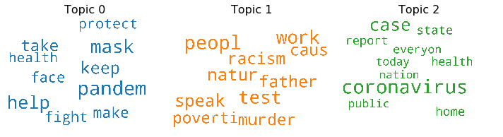

```python
# 1. Wordcloud of Top N words in each topic
from matplotlib import pyplot as plt
from wordcloud import WordCloud, STOPWORDS
import matplotlib.colors as mcolors

cols = [color for name, color in mcolors.TABLEAU_COLORS.items()]  # more colors: 'mcolors.XKCD_COLORS'

cloud = WordCloud(stopwords=stop_words,
                  background_color='white',
                  width=2500,
                  height=1800,
                  max_words=10,
                  colormap='tab10',
                  color_func=lambda *args, **kwargs: cols[i],
                  prefer_horizontal=1.0)

topics = lda_model_bow.show_topics(formatted=False)

fig, axes = plt.subplots(1, 3, figsize=(10,10), sharex=True, sharey=True)

for i, ax in enumerate(axes.flatten()):
    if i >= lda_model_bow.num_topics: break
    fig.add_subplot(ax)
    topic_words = dict(topics[i][1])
    cloud.generate_from_frequencies(topic_words, max_font_size=300)
    plt.gca().imshow(cloud)
    plt.gca().set_title('Topic ' + str(i), fontdict=dict(size=16))
    plt.gca().axis('off')


plt.subplots_adjust(wspace=0, hspace=0)
plt.axis('off')
plt.margins(x=0, y=0)
plt.tight_layout()
plt.show()
```

# 9. Dominant Topic for each tweet

So far we built a topic model with tuned hyper parameters. Now, let's find out which topic does each of the tweets belong to. We'll do this by running the tweet through the model. The model would return with a list of topic_id and corresponding Percentage contribution of each topic in the tweet. We'll take the topic with the highest percentage contribution as the dominant topic for the tweet.

```python
def format_topics_sentences(ldamodel=None, corpus=corpus, texts=None):
    # Init output
    sent_topics_df = pd.DataFrame()

    # Let's get the topics and their keywords
    topicsDF = pd.DataFrame()
    for topic_id in range(lda_model_bow.num_topics):
        wp = lda_model_bow.show_topic(topic_id)
        topic_keywords = ", ".join([word for word, prop in wp])
        topicsDF = topicsDF.append(pd.Series([int(topic_id),topic_keywords]),ignore_index=True)
    topicsDF.columns=['Topic_Num','Keywords']

    # Get main topic in each document
    for i, row_list in enumerate(ldamodel[corpus]):
        row = sorted(row_list, key=lambda x: (x[1]), reverse=True)

        # Get the Dominant topic, Perc Contribution and Keywords for each document
        (topic_num, prop_topic) = row[0]
        sent_topics_df = sent_topics_df.append(pd.Series([int(topic_num), round(prop_topic,4)]), ignore_index=True)
    sent_topics_df.columns = ['Topic_Num', 'Perc_Contribution']

    # Merge with topicsDF to add the Keywords from each topic
    sent_topics_df = sent_topics_df.merge(topicsDF, on='Topic_Num', how='left')

    # Add original text to the end of the output
    contents = pd.Series(texts)
    sent_topics_df = pd.concat([sent_topics_df, contents], axis=1)
    return(sent_topics_df)


tweet_topics = format_topics_sentences(ldamodel=lda_model_bow, corpus=bow_corpus, texts=processed_tweets)

# Format
tweet_topics = tweet_topics.reset_index()
tweet_topics.columns = ['Tweet_Num', 'Dominant_Topic', 'Topic_Perc_Contrib', 'Keywords', 'Text']
tweet_topics.head(10)
```

|  | Tweet_Num | Dominant_Topic | Topic_Perc_Contrib | Keywords | Text |
| --- | --- | --- | --- | --- | --- |
| 0 | 0 | 2.0 | 0.8771 | coronavirus, case, home, state, report, everyon, public, health, today, nation | [state, health, offic, scott, harri, issu, stay, home, order, strict, quarantin, requir, read, full] |
| 1 | 1 | 2.0 | 0.5204 | coronavirus, case, home, state, report, everyon, public, health, today, nation | [thank, nurs, help, keep, healthi, covid, coronavirus] |
| 2 | 2 | 1.0 | 0.6634 | peopl, work, test, natur, speak, father, murder, caus, racism, poverti | [togetherapart, slow, spread, covid] |
| 3 | 3 | 2.0 | 0.6641 | coronavirus, case, home, state, report, everyon, public, health, today, nation | [smoker, greater, risk, contract, coronavirus, elli, cannon, say, equal, risk, contract] |
| 4 | 4 | 0.0 | 0.3333 | pandem, mask, help, keep, take, make, fight, face, protect, health | [video, model, scan, show, extent, covid, damag, lung, tissu, stayhom] |
| 5 | 5 | 1.0 | 0.7628 | peopl, work, test, natur, speak, father, murder, caus, racism, poverti | [leader, hous, parti, caucus, arizona, andi, bigg, think, spread, covid, much, possib] |
| 6 | 6 | 1.0 | 0.6654 | peopl, work, test, natur, speak, father, murder, caus, racism, poverti | [covid, test, administ] |
| 7 | 7 | 0.0 | 0.9115 | pandem, mask, help, keep, take, make, fight, face, protect, health | [keep, think, master, public, health, write, doctor, dissert, global, effort, tackl, aid, pandem] |
| 8 | 8 | 0.0 | 0.5726 | pandem, mask, help, keep, take, make, fight, face, protect, health | [ceylonblacktea, rich, theaflavin, help, increas, human, immun, covid, srilankatea, industri, successfu] |
| 9 | 9 | 1.0 | 0.8054 | peopl, work, test, natur, speak, father, murder, caus, racism, poverti | [peopl, first, group, hospit, sick, place, infirmari, convert, convent] |

In the above section, we identified dominant topic for each tweet. Now, let's look at the perc contribution of each topic in a tweet and then visualize the dominant topic for the same.

```python
# Create Document - Topic Matrix
lda_output = lda_model_bow[bow_corpus]

df_document_topic = pd.DataFrame()
for i in range(len(lda_output)):
    df_document_topic
# column names
topicnames = ["Topic" + str(i) for i in range(lda_model_bow.num_topics)]

# index names
docnames = ["Tweet" + str(i) for i in range(len(processed_tweets))]

# Make the pandas dataframe
df_document_topic = pd.DataFrame(lda_output, columns=topicnames, index=docnames)
for topic in topicnames:
    df_document_topic[topic] = df_document_topic[topic].apply(lambda x: np.round(x[1],2))

# Get dominant topic for each document
dominant_topic = np.argmax(df_document_topic.values, axis=1)
df_document_topic['dominant_topic'] = dominant_topic

# Styling
def color_green(val):
    color = 'green' if val > .33 else 'black'
    return 'color: {col}'.format(col=color)

def make_bold(val):
    weight = 700 if val > .1 else 400
    return 'font-weight: {weight}'.format(weight=weight)

# Apply Style
df_document_topics = df_document_topic.head(10).style.applymap(color_green).applymap(make_bold)
df_document_topics
```

|  | Topic0 | Topic1 | Topic2 | dominant_topic |
| --- | --- | --- | --- | --- |
| Tweet0 | 0.06 | 0.06 | 0.88 | 2 |
| Tweet1 | 0.41 | 0.07 | 0.52 | 2 |
| Tweet2 | 0.17 | 0.66 | 0.17 | 1 |
| Tweet3 | 0.12 | 0.22 | 0.66 | 2 |
| Tweet4 | 0.33 | 0.33 | 0.33 | 0 |
| Tweet5 | 0.12 | 0.76 | 0.11 | 1 |
| Tweet6 | 0.17 | 0.67 | 0.17 | 1 |
| Tweet7 | 0.91 | 0.04 | 0.04 | 0 |
| Tweet8 | 0.57 | 0.09 | 0.34 | 0 |
| Tweet9 | 0.1 | 0.81 | 0.09 | 1 |

It's interesting to see that some of the tweets were equally distributed across all topics. We can analyze this further and build a model to classify this better in the future.

# 10. Most representative tweet for each topic

In this section, let's find out the tweet that matches with the topic strongly. For this, we'll group all tweets by their corresponding dominant topics. For each topic, we'll identify the tweet with highest topic percentage contribution.

```python
# sent_topics_sorteddf_mallet -> topic_sent
topic_sent = pd.DataFrame()
topic_sent_grpd = tweet_topics.groupby('Dominant_Topic')

for i, grp in topic_sent_grpd:
    topic_sent = pd.concat([topic_sent, grp.sort_values(['Topic_Perc_Contrib'], ascending=False).head(1)], axis=0)

# Reset Index
topic_sent.reset_index(drop=True, inplace=True)

# Format
topic_sent.columns = ['Tweet_Num','Topic_Num', "Topic_Perc_Contrib", "Keywords", "Representative Text"]
topic_sent = topic_sent.reindex(columns=['Topic_Num','Tweet_Num', "Topic_Perc_Contrib", "Keywords", "Representative Text"])

# Show
topic_sent.head()
```

|  | Topic_Num | Tweet_Num | Topic_Perc_Contrib | Keywords | Representative Text |
| --- | --- | --- | --- | --- | --- |
| 0 | 0.0 | 271 | 0.9115 | pandem, mask, help, keep, take, make, fight, face, protect, health | [keep, think, master, public, health, write, doctor, dissert, global, effort, tackl, aid, pandem] |
| 1 | 1.0 | 991 | 0.9327 | peopl, work, test, natur, speak, father, murder, caus, racism, poverti | [natur, caus, father, murder, work, racism, poverti, speak, trut] |
| 2 | 2.0 | 114 | 0.9387 | coronavirus, case, home, state, report, everyon, public, health, today, nation | [coronavirus, affect, everyon, discrimin, basi, religion, cast, rich, poor, either] |

# 11. Topic distribution amongst all tweets

Finally, let's identify how are different topics distributed amongst all tweets and compute the contribution of each topic over all tweets.

```python
# Number of tweets per topic
topic_counts = tweet_topics.Dominant_Topic.value_counts()
topic_counts = topic_counts.rename_axis('Topic_Num').reset_index(name='Tweet_Counts')

# Percentage of tweets for each topic
topic_counts['Topic_Contribution'] = round(topic_counts.Tweet_Counts /topic_counts.Tweet_Counts.sum(), 2)
#topic_contribution = round(topic_counts/topic_counts.sum(), 2)

# Topic information.
topics = topic_sent[['Topic_Num','Keywords']]
topics = topics.merge(topic_counts, on='Topic_Num', how='left')
topics
```

|  | Topic_Num | Keywords | Tweet_Counts | Topic_Contribution |
| --- | --- | --- | --- | --- |
| 0 | 0.0 | pandem, mask, help, keep, take, make, fight, face, protect, health | 458 | 0.46 |
| 1 | 1.0 | peopl, work, test, natur, speak, father, murder, caus, racism, poverti | 254 | 0.25 |
| 2 | 2.0 | coronavirus, case, home, state, report, everyon, public, health, today, nation | 288 | 0.29 |

# 12. Conclusion

No one was expecting that the whole world will be stunned by COVID 19 outbreak in 2020. It has been a few months since different parts around the world has gone under self-quarantine. With so much happening around the world we were curious to know what's on top of mind on everyone around the world regarding COVID 19. We implemented Topic Modeling using tweets from around the world to answer this question.

We started off with collecting the data from Twitter using Tweepy. Then we went over different preprocessing techniques specific to tweets as well as generic text preprocessing. Then we looked into two models for text representation namely Bag of Words(BOW) and TF-IDF. Followed by that, we built LDA models using both text representations. We talked about performance evaluations for topic modeling to determine the quality of the topic segregations.

With the modeling and evaluation pipeline in place, we tuned the Number of Topics hyper parameter and visualized the best model using PyLDAVis. With this we built a successful Topic Models.

After that, we went ahead analyzing the topics clustered. We started this by generating the word clouds for each topic using the top 10 keywords. Then we looked into how each tweet is distributed into different topics and found out the dominant topic for each tweet. We also identitied the tweet that best matches with each topic. Finally, we looked at the topic distribution and topic contribution amongst all the tweets.

Hope you enjoyed reading through this article. I would greatly appreciate it if you leave your thoughts in the comments section below.